# Supervised learning classification models

Alisha Gumber

11/23/2019

```r
HCV_bin <- read_csv("/Users/alishagumber/Desktop/Machine\ Learning/Hep_C_dataset/HCV-Egy-Data.csv")
# filter dataset for all variables I will be using (drop columns 17-27)
HCV_bin <- HCV_bin[-c(17:28)]
```

1 = yes, 2 = no 1 = male, 2 = f convert to binary (1 and 0) Now 1 = yes, 0 = no male = 0, female = 1

```r
HCV_bin$Fever <- ifelse(HCV_bin$Fever == 2, 0, 1)
HCV_bin$Gender <- ifelse(HCV_bin$Gender == 2, 1, 0)
HCV_bin$`Nausea/Vomting` <- ifelse(HCV_bin$`Nausea/Vomting` == 2, 0, 1)
HCV_bin$Headache <- ifelse(HCV_bin$Headache == 2, 0, 1)
HCV_bin$Diarrhea <- ifelse(HCV_bin$Diarrhea == 2, 0, 1)
HCV_bin$`Fatigue & generalized bone ache` <- ifelse(HCV_bin$`Fatigue & generalized bone ache` == 2, 0, 1)
HCV_bin$Jaundice <- ifelse(HCV_bin$Jaundice == 2, 0, 1)
HCV_bin$`Epigastric pain` <- ifelse(HCV_bin$`Epigastric pain` == 2, 0, 1)

#View(HCV_bin)
```

Since many models work best with binary responses, i’m converting the histological stage into a binary response, with either a diagnosis of severe (stages 3 and 4) or not severe (stage 1 and 2)

```r
# convert histological stage to binary response
Severe = ifelse(HCV_bin$`Baselinehistological staging`>=3, "Severe", "Not_Severe")
HCV = data.frame(HCV_bin, Severe)

head(HCV)
```

```
##   Age Gender BMI Fever Nausea.Vomting Headache Diarrhea
## 1  56      0  35     0              1        1        1
## 2  46      0  29     1              0        0        1
## 3  57      0  33     0              0        0        0
## 4  49      1  33     1              0        1        0
## 5  59      0  32     1              1        0        1
## 6  58      1  22     0              0        0        1
##   Fatigue...generalized.bone.ache Jaundice Epigastric.pain   WBC     RBC HGB
## 1                               0        0               0  7425 4248807  14
## 2                               0        0               1 12101 4429425  10
## 3                               1        1               1  4178 4621191  12
## 4                               1        0               1  6490 4794631  10
## 5                               0        0               0  3661 4606375  11
## 6                               0        0               1 11785 3882456  15
##     Plat AST.1 ALT.1 Baselinehistological.staging     Severe
## 1 112132    99    84                            2 Not_Severe
## 2 129367    91   123                            2 Not_Severe
## 3 151522   113    49                            4     Severe
## 4 146457    43    64                            3     Severe
## 5 187684    99   104                            1 Not_Severe
## 6 131228    66   104                            4     Severe
```

Since all the numeric variables are on different scales, I will scale the data

```r
HCV[1:16] <- lapply(HCV[1:16], function(x) c(scale(x)))
```

```r
# rename some columns for easier analysis
colnames(HCV)[colnames(HCV)=="Fatigue...generalized.bone.ache"] <- "fatigue_and_bodyache"
colnames(HCV)[colnames(HCV)=="Epigastric.pain"] <- "epigastric_pain"
colnames(HCV)[colnames(HCV)=="Baselinehistological.staging" ] <- "histological_stage"
colnames(HCV)[colnames(HCV)=="AST.1" ] <- "AST_1"
colnames(HCV)[colnames(HCV)=="ALT.1" ] <- "ALT_1"
colnames(HCV)[colnames(HCV)=="Nausea.Vomting" ] <- "nausea_vomiting"
```

## Supervised Learning Models

I will be trying a few different classification models to see which has the best outcome on this dataset. The models i’ll be using include, Support Vector Machine, Logistic Regression, Random Forest, and Naive Bayes. I will not be trying linear discriminant analysis. LDA is known to be used for well separated classes, and good for more than 2 response classes. It also assumes a normal distribution with a class specific mean and common variance, which does not apply to my dataset. I will first use all the features to train the model, create a Receiver Opterating Characteristic (ROC) curve and find the Area Under the Curve (AUC). I will then predict on the test set and check the accuracy. Then, I’m going to remove some of the variables based on my backward elimination feature selection, and compare results to see if feature selection improved the model’s accuracy.

## Support Vector Machine

```r
# set seed for reproducibility
set.seed(30)

# split data into training and testing (75/25)
train <- floor(0.75 * nrow(HCV))
train_pos <- sample(seq_len(nrow(HCV)), size = train)

training_set <- HCV[train_pos,]
testing_set <- HCV[-train_pos,]

# look at dimensions of training/testing set
dim(training_set) # 1038 observation in train set, with 18 variables
```

```
## [1] 1038   18
```

```r
dim(testing_set) # 347 observations in test set, with 18 variables
```

```
## [1] 347  18
```

SVM linear kernel method:

```r
set.seed(30)
control = trainControl(method = "repeatedcv", repeats = 5, classProbs = T, savePredictions = T)

svm = train(Severe ~ Age + Gender + BMI + Fever + nausea_vomiting + Headache + Diarrhea + fatigue_and_bodyache + Jaundice + epigastric_pain + WBC + RBC + HGB + Plat + AST_1 + ALT_1,  data = training_set, method = "svmLinear", tuneLength = 10, trControl = control)

# Severe ~ Age + Gender + BMI + Fever + nausea_vomiting + Headache + Diarrhea + fatigue_and_bodyache + Jaundice + epigastric_pain + WBC + RBC + HGB + Plat + AST_1 + ALT_1
svm
```

```
## Support Vector Machines with Linear Kernel
##
## 1038 samples
##   16 predictor
##    2 classes: 'Not_Severe', 'Severe'
##
## No pre-processing
## Resampling: Cross-Validated (10 fold, repeated 5 times)
## Summary of sample sizes: 934, 934, 934, 934, 935, 935, ...
## Resampling results:
##
##   Accuracy   Kappa
##   0.5200187  0.01404011
##
## Tuning parameter 'C' was held constant at a value of 1
```

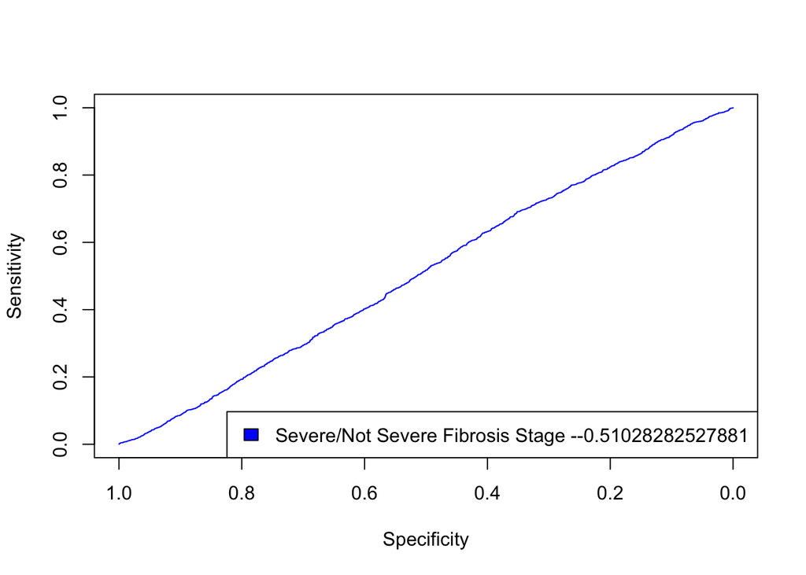

```r
# Plot ROC curve with AUC results
plot(x = roc(predictor = svm$pred$Severe, response = svm$pred$obs)$specificities, y = roc(predictor = svm$pred$Severe, response = svm$pred$obs)$sensitivities, col= "blue", xlim = c(1, 0), type ="l", ylab = "Sensitivity", xlab = "Specificity")
legend("bottomright", legend = paste("Severe/Not Severe Fibrosis Stage --",
                                     roc(predictor = svm$pred$Severe,
                                         response = svm$pred$obs)$auc
, sep = ""), col = c("blue"), fill = c("blue"))
```

Perform model on test set and make confusion matrix

```r
svm_test = predict(svm, newdata = testing_set)
confusionMatrix(svm_test, reference = testing_set$Severe)
```

```
## Confusion Matrix and Statistics
##
##             Reference
## Prediction   Not_Severe Severe
##   Not_Severe          3      9
##   Severe            165    170
##
##                Accuracy : 0.4986
##                  95% CI : (0.4447, 0.5524)
##     No Information Rate : 0.5159
##     P-Value [Acc > NIR] : 0.7575
##
##                   Kappa : -0.0334
##
##  Mcnemar's Test P-Value : <2e-16
##
##             Sensitivity : 0.017857
##             Specificity : 0.949721
##          Pos Pred Value : 0.250000
##          Neg Pred Value : 0.507463
##              Prevalence : 0.484150
##          Detection Rate : 0.008646
##    Detection Prevalence : 0.034582
##       Balanced Accuracy : 0.483789
##
##        'Positive' Class : Not_Severe
##
```

**Using an SVM model with a linear kernel, the AUC was ~0.51 and an accuracy of 0.4986 after performing the test data.**

SVM with radial kernel method:

```r
set.seed(30)
control = trainControl(method = "repeatedcv", repeats = 5, classProbs = T, savePredictions = T)

svm_rad = train(Severe ~ Age + Gender + BMI + Fever + nausea_vomiting + Headache + Diarrhea + fatigue_and_bodyache + Jaundice + epigastric_pain + WBC + RBC + HGB + Plat + AST_1 + ALT_1,  data = training_set, method = "svmRadial", tuneLength = 10, trControl = control)

svm_rad
```

```
## Support Vector Machines with Radial Basis Function Kernel
##
## 1038 samples
##   16 predictor
##    2 classes: 'Not_Severe', 'Severe'
##
## No pre-processing
## Resampling: Cross-Validated (10 fold, repeated 5 times)
## Summary of sample sizes: 934, 934, 934, 934, 935, 935, ...
## Resampling results across tuning parameters:
##
##   C       Accuracy   Kappa
##     0.25  0.5169436   0.0085416304
##     0.50  0.5109727  -0.0061410334
##     1.00  0.5069399  -0.0132176031
##     2.00  0.5148245  -0.0006829725
##     4.00  0.5113742  -0.0071241787
##     8.00  0.5057804  -0.0178224859
##    16.00  0.5034858  -0.0172252455
##    32.00  0.5163723   0.0105462342
##    64.00  0.5290777   0.0370333808
##   128.00  0.5290963   0.0369271856
##
## Tuning parameter 'sigma' was held constant at a value of 0.03517378
## Accuracy was used to select the optimal model using the largest value.
## The final values used for the model were sigma = 0.03517378 and C = 128.
```

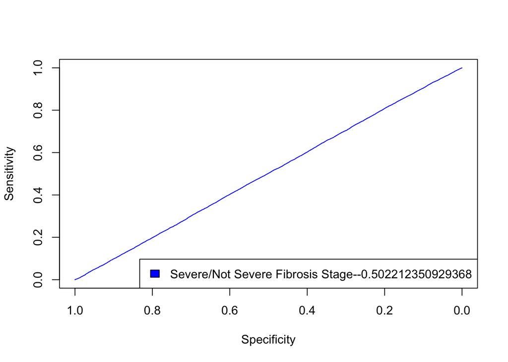

```r
# Plot ROC curve with AUC results
plot(x = roc(predictor = svm_rad$pred$Severe, response = svm_rad$pred$obs)$specificities, y = roc(predictor = svm_rad$pred$Severe, response = svm_rad$pred$obs)$sensitivities, col= "blue", xlim = c(1, 0), type ="l", ylab = "Sensitivity", xlab = "Specificity")
legend("bottomright", legend = paste("Severe/Not Severe Fibrosis Stage--",
                                     roc(predictor = svm_rad$pred$Severe,
                                         response = svm_rad$pred$obs)$auc
, sep = ""), col = c("blue"), fill = c("blue"))
```

```r
svm_test_rad = predict(svm_rad, newdata = testing_set)
confusionMatrix(svm_test_rad, reference = testing_set$Severe)
```

```
## Confusion Matrix and Statistics
##
##             Reference
## Prediction   Not_Severe Severe
##   Not_Severe         19     21
##   Severe            149    158
##
##                Accuracy : 0.5101
##                  95% CI : (0.4562, 0.5638)
##     No Information Rate : 0.5159
##     P-Value [Acc > NIR] : 0.606
##
##                   Kappa : -0.0043
##
##  Mcnemar's Test P-Value : <2e-16
##
##             Sensitivity : 0.11310
##             Specificity : 0.88268
##          Pos Pred Value : 0.47500
##          Neg Pred Value : 0.51466
##              Prevalence : 0.48415
##          Detection Rate : 0.05476
##    Detection Prevalence : 0.11527
##       Balanced Accuracy : 0.49789
##
##        'Positive' Class : Not_Severe
##
```

**Using an SVM model with a radial kernel, the AUC was ~0.50 and an accuracy of 0.5101 after performing the test data.**

SVM with feature selection:

```r
set.seed(30)
control = trainControl(method = "repeatedcv", repeats = 5, classProbs = T, savePredictions = T)

svm_feat = train(Severe ~ Age + Gender + BMI + nausea_vomiting + epigastric_pain +
    Plat + ALT_1,  data = training_set, method = "svmLinear", tuneLength = 10, trControl = control)

svm_feat
```

```
## Support Vector Machines with Linear Kernel
##
## 1038 samples
##    7 predictor
##    2 classes: 'Not_Severe', 'Severe'
##
## No pre-processing
## Resampling: Cross-Validated (10 fold, repeated 5 times)
## Summary of sample sizes: 934, 934, 934, 934, 935, 935, ...
## Resampling results:
##
##   Accuracy   Kappa
##   0.5192681  0.01301886
##
## Tuning parameter 'C' was held constant at a value of 1
```

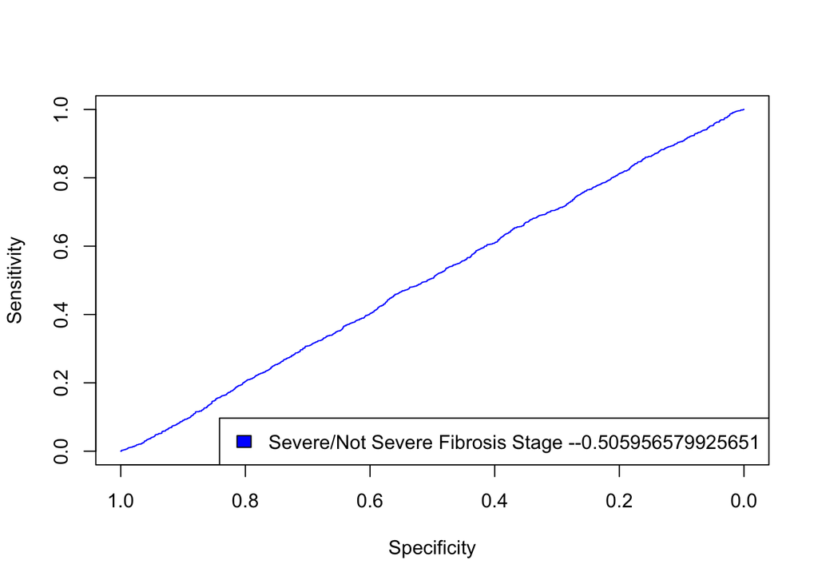

```r
# Plot ROC curve with AUC results
plot(x = roc(predictor = svm_feat$pred$Severe, response = svm_feat$pred$obs)$specificities, y = roc(predictor = svm_feat$pred$Severe, response = svm_feat$pred$obs)$sensitivities, col= "blue", xlim = c(1, 0), type ="l", ylab = "Sensitivity", xlab = "Specificity")
legend("bottomright", legend = paste("Severe/Not Severe Fibrosis Stage --",
                                     roc(predictor = svm_feat$pred$Severe,
                                         response = svm_feat$pred$obs)$auc
, sep = ""), col = c("blue"), fill = c("blue"))
```

```r
svm_pred_feat = predict(svm_feat, newdata = testing_set)
confusionMatrix(svm_pred_feat, reference = testing_set$Severe)
```

```
## Confusion Matrix and Statistics
##
##             Reference
## Prediction   Not_Severe Severe
##   Not_Severe         60     50
##   Severe            108    129
##
##                Accuracy : 0.5447
##                  95% CI : (0.4906, 0.5979)
##     No Information Rate : 0.5159
##     P-Value [Acc > NIR] : 0.1537
##
##                   Kappa : 0.0786
##
##  Mcnemar's Test P-Value : 5.769e-06
##
##             Sensitivity : 0.3571
##             Specificity : 0.7207
##          Pos Pred Value : 0.5455
##          Neg Pred Value : 0.5443
##              Prevalence : 0.4841
##          Detection Rate : 0.1729
##    Detection Prevalence : 0.3170
##       Balanced Accuracy : 0.5389
##
##        'Positive' Class : Not_Severe
##
```

## Logistic Regression

```r
set.seed(30)
ctrl <- trainControl(method = "repeatedcv", repeats = 15,classProbs = T,
                     savePredictions = T)

# create model - logistic regression is a bionomial general linear model.
logistic_regression <- train(Severe ~ Age + Gender + BMI + Fever + nausea_vomiting + Headache + Diarrhea + fatigue_and_bodyache + Jaundice + epigastric_pain + WBC + RBC + HGB + Plat + AST_1 + ALT_1, data = training_set, method = "glm", family= "binomial", trControl = ctrl)

logistic_regression
```

```
## Generalized Linear Model
##
## 1038 samples
##   16 predictor
##    2 classes: 'Not_Severe', 'Severe'
##
## No pre-processing
## Resampling: Cross-Validated (10 fold, repeated 15 times)
## Summary of sample sizes: 934, 934, 934, 934, 935, 935, ...
## Resampling results:
##
##   Accuracy   Kappa
##   0.5247268  0.04293012
```

```r
confusionMatrix(logistic_regression)
```

```
## Cross-Validated (10 fold, repeated 15 times) Confusion Matrix
##
## (entries are percentual average cell counts across resamples)
##
##             Reference
## Prediction   Not_Severe Severe
##   Not_Severe       20.7   20.0
##   Severe           27.5   31.8
##
##  Accuracy (average) : 0.5247
```

Visualize with ROC curve

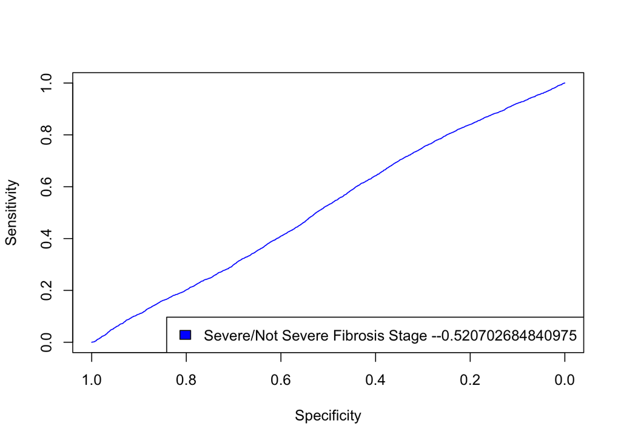

```r
plot(x = roc(predictor = logistic_regression$pred$Severe,
             response = logistic_regression$pred$obs)$specificities,
     y = roc(predictor = logistic_regression$pred$Severe,
             response = logistic_regression$pred$obs)$sensitivities,
     col= "blue", xlim = c(1, 0), type ="l", ylab = "Sensitivity",
     xlab = "Specificity")
legend("bottomright", legend = paste("Severe/Not Severe Fibrosis Stage --",
                                     roc(predictor = logistic_regression$pred$Severe,
                                         response = logistic_regression$pred$obs)$auc
, sep = ""), col = c("blue"), fill = c("blue"))
```

**Logistic Regression with all features has an AUC of 0.52**

Test on independent test set

```r
#predict iris species using Sepal legth
log_reg_pred <- predict(logistic_regression, newdata = testing_set)

#confusion matrix
confusionMatrix(log_reg_pred,
                reference = testing_set$Severe)
```

```
## Confusion Matrix and Statistics
##
##             Reference
## Prediction   Not_Severe Severe
##   Not_Severe         74     82
##   Severe             94     97
##
##                Accuracy : 0.4928
##                  95% CI : (0.439, 0.5467)
##     No Information Rate : 0.5159
##     P-Value [Acc > NIR] : 0.8194
##
##                   Kappa : -0.0177
##
##  Mcnemar's Test P-Value : 0.4070
##
##             Sensitivity : 0.4405
##             Specificity : 0.5419
##          Pos Pred Value : 0.4744
##          Neg Pred Value : 0.5079
##              Prevalence : 0.4841
##          Detection Rate : 0.2133
##    Detection Prevalence : 0.4496
##       Balanced Accuracy : 0.4912
##
##        'Positive' Class : Not_Severe
##
```

**A logistic regression model for predicting severe or not severe liver fibrosis had an AUC of 0.52. The accuracy of the test set was 0.493.**

Logistic Regression with feature selection

```r
ctrl <- trainControl(method = "repeatedcv", repeats = 15,classProbs = T,
                     savePredictions = T)

# create model - logistic regression is a bionomial general linear model.
log_reg2 <- train(Severe ~ Age + Gender + BMI + nausea_vomiting + epigastric_pain + Plat + ALT_1, data = training_set, method = "glm", family= "binomial", trControl = ctrl)


log_reg2
```

```
## Generalized Linear Model
##
## 1038 samples
##    7 predictor
##    2 classes: 'Not_Severe', 'Severe'
##
## No pre-processing
## Resampling: Cross-Validated (10 fold, repeated 15 times)
## Summary of sample sizes: 934, 934, 934, 934, 934, 935, ...
## Resampling results:
##
##   Accuracy   Kappa
##   0.5404867  0.07295492
```

```r
summary(log_reg2)
```

```
##
## Call:
## NULL
##
## Deviance Residuals:
##     Min       1Q   Median       3Q      Max
## -1.5195  -1.1919   0.9654   1.1347   1.4359
##
## Coefficients:
##                 Estimate Std. Error z value Pr(>|z|)
## (Intercept)      0.06317    0.06267   1.008   0.3135
## Age             -0.11264    0.06341  -1.776   0.0757 .
## Gender           0.08542    0.06277   1.361   0.1736
## BMI             -0.15388    0.06321  -2.434   0.0149 *
## nausea_vomiting -0.11938    0.06334  -1.885   0.0595 .
## epigastric_pain  0.07166    0.06297   1.138   0.2551
## Plat            -0.02837    0.06281  -0.452   0.6515
## ALT_1            0.03290    0.06233   0.528   0.5976
## ---
## Signif. codes:  0 '***' 0.001 '**' 0.01 '*' 0.05 '.' 0.1 ' ' 1
##
## (Dispersion parameter for binomial family taken to be 1)
##
##     Null deviance: 1437.6  on 1037  degrees of freedom
## Residual deviance: 1421.5  on 1030  degrees of freedom
## AIC: 1437.5
##
## Number of Fisher Scoring iterations: 4
```

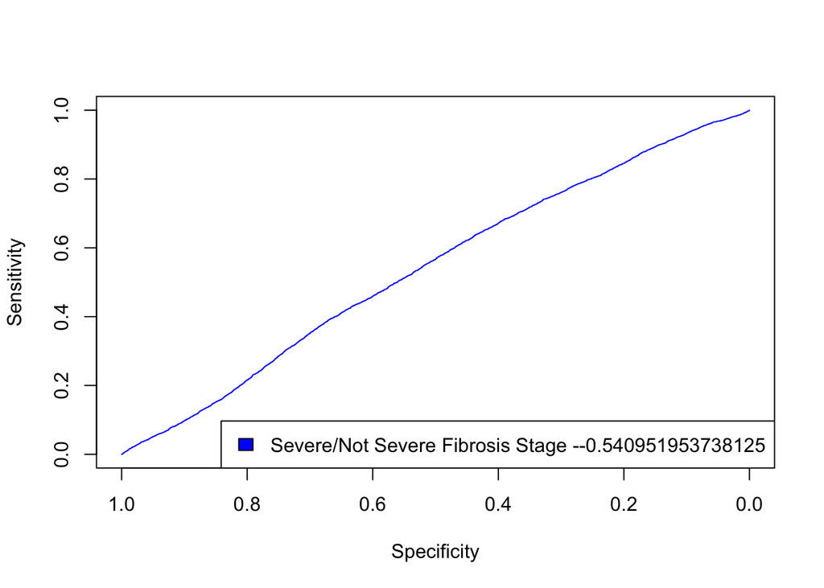

```r
plot(x = roc(predictor = log_reg2$pred$Severe,
             response = log_reg2$pred$obs)$specificities,
     y = roc(predictor = log_reg2$pred$Severe,
             response = log_reg2$pred$obs)$sensitivities,
     col= "blue", xlim = c(1, 0), type ="l", ylab = "Sensitivity",
     xlab = "Specificity")
legend("bottomright", legend = paste("Severe/Not Severe Fibrosis Stage --",
                                     roc(predictor = log_reg2$pred$Severe,
                                         response = log_reg2$pred$obs)$auc
, sep = ""), col = c("blue"), fill = c("blue"))
```

```r
# predict on test set
log_reg_pred2 <- predict(log_reg2, newdata = testing_set)

#confusion matrix
confusionMatrix(log_reg_pred2,
                reference = testing_set$Severe)
```

```
## Confusion Matrix and Statistics
##
##             Reference
## Prediction   Not_Severe Severe
##   Not_Severe         84     77
##   Severe             84    102
##
##                Accuracy : 0.536
##                  95% CI : (0.482, 0.5894)
##     No Information Rate : 0.5159
##     P-Value [Acc > NIR] : 0.2426
##
##                   Kappa : 0.0699
##
##  Mcnemar's Test P-Value : 0.6363
##
##             Sensitivity : 0.5000
##             Specificity : 0.5698
##          Pos Pred Value : 0.5217
##          Neg Pred Value : 0.5484
##              Prevalence : 0.4841
##          Detection Rate : 0.2421
##    Detection Prevalence : 0.4640
##       Balanced Accuracy : 0.5349
##
##        'Positive' Class : Not_Severe
##
```

**Logistic Regression with feature selection (only using 7 features) improved model to AUC of 0.54. and accuracy of 0.536 on independent test set.**

## Random Forest

```r
# fit model on training set
set.seed(123)
model_rf <- train(Severe ~ Age + Gender + BMI + Fever + nausea_vomiting + Headache + Diarrhea + fatigue_and_bodyache + Jaundice + epigastric_pain + WBC + RBC + HGB + Plat + AST_1 + ALT_1, data = training_set, method = "rf", trControl = trainControl("cv", number = 10), importance = TRUE)

model_rf$bestTune
```

```
##   mtry
## 2    9
```

```r
model_rf$finalModel
```

```
##
## Call:
##  randomForest(x = x, y = y, mtry = param$mtry, importance = TRUE)
##                Type of random forest: classification
##                      Number of trees: 500
## No. of variables tried at each split: 9
##
##         OOB estimate of  error rate: 51.73%
## Confusion matrix:
##            Not_Severe Severe class.error
## Not_Severe        207    293   0.5860000
## Severe            244    294   0.4535316
```

```r
# make prediction on test data
predicted_rf <- model_rf %>% predict(testing_set)
head(predicted_rf)
```

```
## [1] Not_Severe Not_Severe Severe     Not_Severe Not_Severe Severe
## Levels: Not_Severe Severe
```

```r
# compute model accuracy
mean(predicted_rf == testing_set$Severe)
```

```
## [1] 0.4783862
```

```r
# check variable importance
importance(model_rf$finalModel)
```

```
##                       Not_Severe      Severe MeanDecreaseAccuracy
## Age                   1.56681706  2.83278843           3.02336881
## Gender                1.46616076 -1.16908004           0.17460914
## BMI                   2.24891756 -0.59817125           1.07091040
## Fever                -1.45222943  1.24780175          -0.04082077
## nausea_vomiting       0.29250371  1.96860897           1.82294710
## Headache             -1.50444561 -0.73490599          -1.67731954
## Diarrhea             -1.23785029 -0.16328411          -1.14021597
## fatigue_and_bodyache -0.35078292  0.87059626           0.36552077
## Jaundice             -0.59724083  0.02346236          -0.33351906
## epigastric_pain       1.46925966  3.08620029           3.26140836
## WBC                  -3.23296940 -0.77832650          -2.72851849
## RBC                  -0.32435545 -1.17485849          -1.05411244
## HGB                   0.19813658 -0.79626288          -0.46453461
## Plat                 -0.02047879 -1.05005262          -0.76094018
## AST_1                -2.02167311 -2.38347861          -3.23215377
## ALT_1                 0.41750364  0.75204510           0.85613975
##                      MeanDecreaseGini
## Age                         53.395173
## Gender                       8.242064
## BMI                         39.944260
## Fever                        8.825131
## nausea_vomiting              8.645778
## Headache                     8.410031
## Diarrhea                     7.782041
## fatigue_and_bodyache         8.402965
## Jaundice                     9.153058
## epigastric_pain              9.079013
## WBC                         67.240400
## RBC                         70.159213
## HGB                         26.319371
## Plat                        71.587405
## AST_1                       60.995508
## ALT_1                       59.500926
```

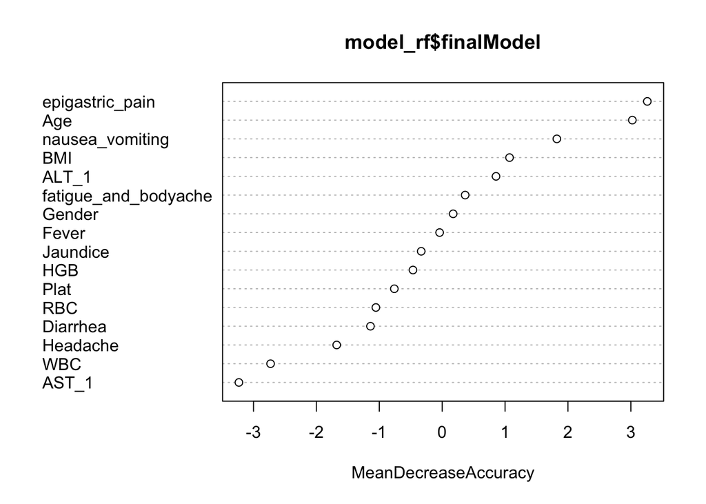

```r
# random forest variable importance plot
# Plot MeanDecreaseAccuracy
varImpPlot(model_rf$finalModel, type = 1)
```

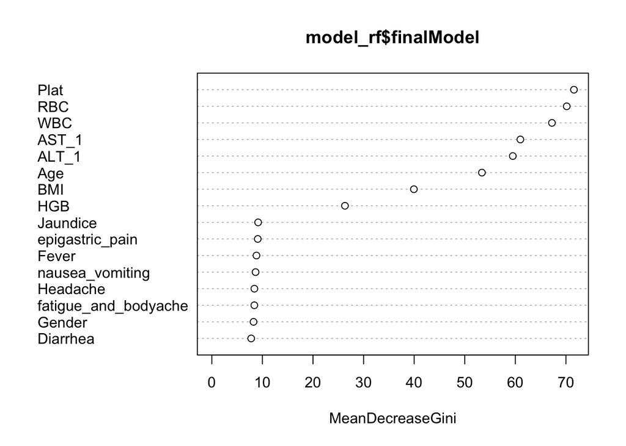

```r
# Plot MeanDecreaseGini
varImpPlot(model_rf$finalModel, type = 2)
```

```r
varImp(model_rf)
```

```
## rf variable importance
##
##                      Importance
## epigastric_pain         100.000
## Age                      98.261
## nausea_vomiting          74.395
## BMI                      67.584
## ALT_1                    62.213
## fatigue_and_bodyache     54.962
## Gender                   52.477
## Fever                    46.880
## Jaundice                 42.758
## HGB                      42.486
## Plat                     37.214
## Diarrhea                 33.525
## RBC                      32.430
## Headache                 24.170
## WBC                       4.395
## AST_1                     0.000
```

**The accuracy of the random forest model was 0.48, with an out-of-bag error of 51.73%. According the the variable importance plot, the most important variables in the random forest model are epigastric pain, age, and nausea/vomiting.**

## Naive Bayes Classification Model

Naive Bayes model assumes all variables are independent of one another.

```r
set.seed(30)
# 10-fold cross validation using trainControl function
train_control <- trainControl(method = "cv", number = 10)

# train naive bayes model
nb <- train(Severe ~ Age + Gender + BMI + Fever + nausea_vomiting + Headache + Diarrhea + fatigue_and_bodyache + Jaundice + epigastric_pain + WBC + RBC + HGB + Plat + AST_1 + ALT_1, data = training_set, method = "nb", trControl = train_control)

confusionMatrix(nb)
```

```
## Cross-Validated (10 fold) Confusion Matrix
##
## (entries are percentual average cell counts across resamples)
##
##             Reference
## Prediction   Not_Severe Severe
##   Not_Severe       20.7   19.4
##   Severe           27.5   32.5
##
##  Accuracy (average) : 0.5318
```

```r
# predict on test set
nb_pred <- predict(nb, newdata = testing_set)

# confusion matrix
confusionMatrix(nb_pred, reference = testing_set$Severe)
```

```
## Confusion Matrix and Statistics
##
##             Reference
## Prediction   Not_Severe Severe
##   Not_Severe         71     82
##   Severe             97     97
##
##                Accuracy : 0.4841
##                  95% CI : (0.4305, 0.5381)
##     No Information Rate : 0.5159
##     P-Value [Acc > NIR] : 0.8916
##
##                   Kappa : -0.0356
##
##  Mcnemar's Test P-Value : 0.2954
##
##             Sensitivity : 0.4226
##             Specificity : 0.5419
##          Pos Pred Value : 0.4641
##          Neg Pred Value : 0.5000
##              Prevalence : 0.4841
##          Detection Rate : 0.2046
##    Detection Prevalence : 0.4409
##       Balanced Accuracy : 0.4823
##
##        'Positive' Class : Not_Severe
##
```

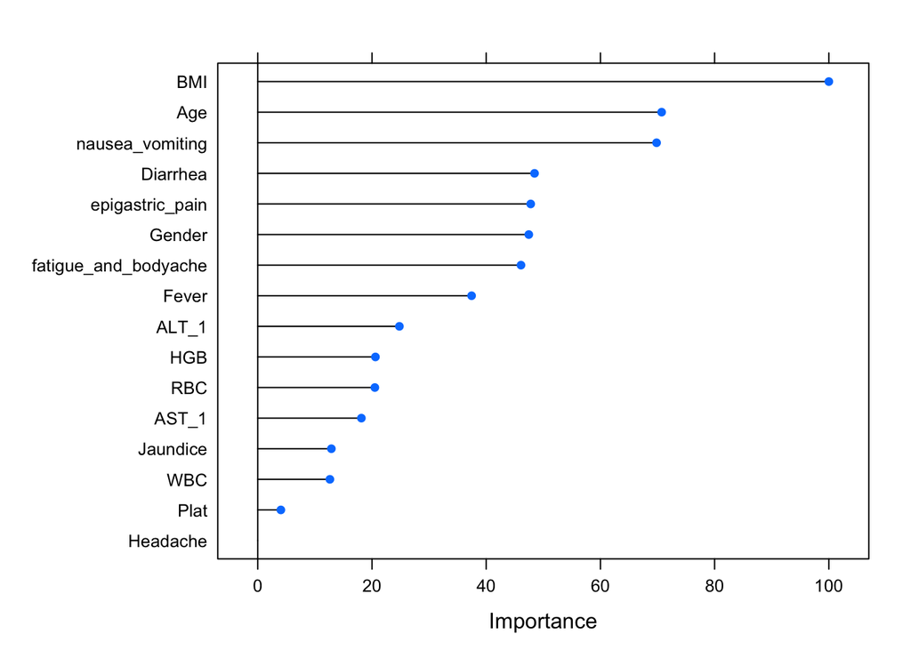

```r
y <- varImp(nb)
plot(y)
```

Naive Bayes with feature selection

```r
set.seed(30)
# train model with feature selection and 10-fold cross validation
nb2 <- train(Severe ~ Age + Gender + BMI + nausea_vomiting + epigastric_pain +
    Plat + ALT_1, data = training_set, method = "nb", trControl = train_control)

confusionMatrix(nb2)
```

```
## Cross-Validated (10 fold) Confusion Matrix
##
## (entries are percentual average cell counts across resamples)
##
##             Reference
## Prediction   Not_Severe Severe
##   Not_Severe       19.6   18.0
##   Severe           28.6   33.8
##
##  Accuracy (average) : 0.5337
```

```r
# predict on test set
nb_pred2 <- predict(nb2, newdata = testing_set)

# confusion matrix
confusionMatrix(nb_pred2, testing_set$Severe)
```

```
## Confusion Matrix and Statistics
##
##             Reference
## Prediction   Not_Severe Severe
##   Not_Severe         79     67
##   Severe             89    112
##
##                Accuracy : 0.5504
##                  95% CI : (0.4964, 0.6036)
##     No Information Rate : 0.5159
##     P-Value [Acc > NIR] : 0.1083
##
##                   Kappa : 0.0963
##
##  Mcnemar's Test P-Value : 0.0927
##
##             Sensitivity : 0.4702
##             Specificity : 0.6257
##          Pos Pred Value : 0.5411
##          Neg Pred Value : 0.5572
##              Prevalence : 0.4841
##          Detection Rate : 0.2277
##    Detection Prevalence : 0.4207
##       Balanced Accuracy : 0.5480
##
##        'Positive' Class : Not_Severe
##
```

**The NB model improved from an accuracy of 0.48 on testing data, to 0.55 with feature selection.**

References: 1. Peleg N, Sneh Arbib O, Issachar A, Cohen-Naftaly M, Braun M, Shlomai A. Noninvasive scoring systems predict hepatic and extra-hepatic cancers in patients with nonalcoholic fatty liver disease. PLoS One. 2018;13(8):e0202393. Published 2018 Aug 14. doi:10.1371/journal.pone.0202393

2. Castera, L. Noninvasive Methods to Assess Liver Disease in Patients With Hepatitis B or C. Gastroenterology. 2012;142(6):1293–1302.